# Paired Designs Have More Power!

Why do paired designs work better than an unpaired equivalent?

Let’s suppose we want to evaluate the effectiveness of watching Slow TV[^1] shows on stress levels. We assess the initial stress level of 30 people, and then assign each person to watch 1 hour of slow TV every night for a week. At the end of the week, we measure the stress level of each person again.

Below, each stage of the analysis process is performed for this data, treating it first as unpaired, and then as paired. Notice the differences between the two analyses.

# Data Summary

## Unpaired

Here is the data summary table for an unpaired design:

| Week | n | Mean | SD |
| --- | --- | --- | --- |
| 0 | 30 | 10.08 | 2.44 |
| 1 | 30 | 9.11 | 2.55 |

## Paired

The mean of the difference between the Final stress measurement and the Initial stress measurement is -0.967 and the standard deviation is 1.342. There are 30 individuals in the study.

# Visually

## Unpaired

We can plot these observations using boxplots:

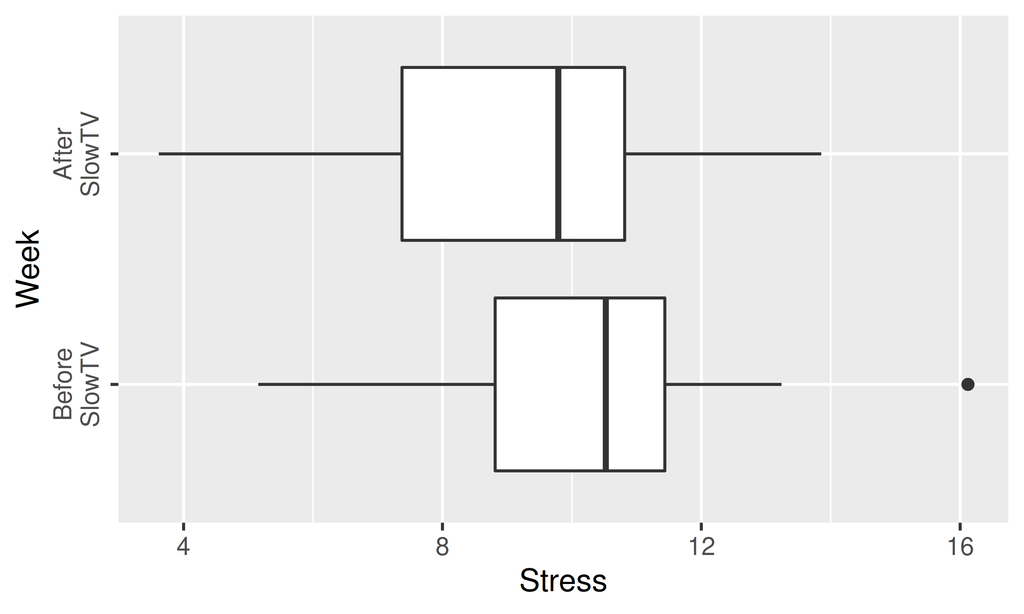

We can see that there is a slight difference in the mean stress level before and after a week of SlowTV, but the distributions overlap significantly; our difference might be due to chance alone.

## Paired

The before-and-after measurements are related - they describe the change in a single person. The boxplots (and the unpaired test) do not account for the fact that each initial observation has a “mate”.

We could also plot these measurements as line segments, where the left end is the initial stress level and the right end is the final stress level:

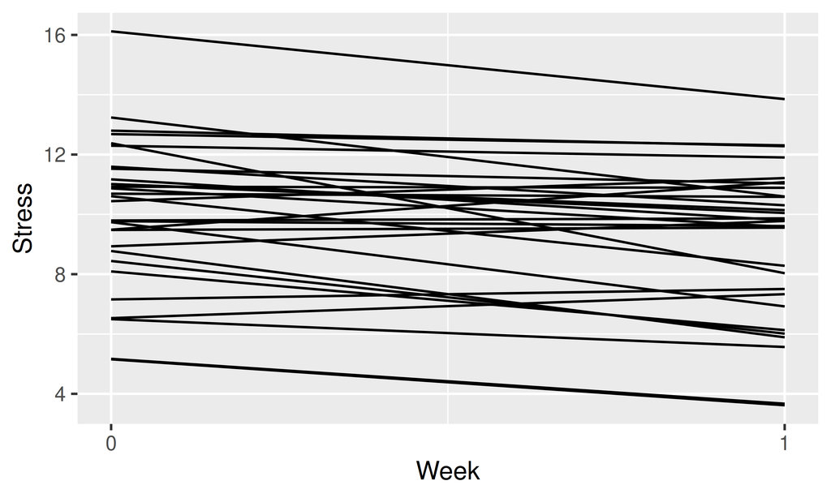

Most of the line segments have a negative (downward) slope, right? That should mean most people had decreased stress after a week of watching SlowTV.

# Null and Alternative Hypothesis

## Unpaired

Our null hypothesis is $H_0: \mu_1 = \mu_0$ where $\mu_1$ is the “after SlowTV” mean stress level and $\mu_0$ is the initial mean stress level.

Our alternative hypothesis is $H_A: \mu_1 < \mu_0$, that is, that the stress level decreases after a week of SlowTV.

## Paired

Our null hypothesis is that $H_0: \mu_D = 0$, that is, on average, there is no difference between the stress level after watching a week of Slow TV and the stress level before watching a week of Slow TV.

Our alternative hypothesis is that $H_A: \mu_D < 0$, that is, on average, there is a decrease in stress level after watching a week of Slow TV.

# Hypothesis Test

## Unpaired

$$\begin{align}
t &= \displaystyle\frac{\overline x_1 - \overline x_0 - 0}{\sqrt{\frac{s_0^2}{n_0} + \frac{s_1^2}{n_1}}}\\
& = \displaystyle\frac{9.113 - 10.08 - 0}{\sqrt{\frac{5.976}{30} + \frac{6.524}{30}}} \\
&=\displaystyle\frac{-0.967 - 0}{\sqrt{0.199 + 0.217}} \\
&= \frac{-0.967}{0.646}\\
&= -1.498
\end{align}$$

As $t = -1.498$, we have little to no evidence against the null hypothesis that SlowTV has no effect on stress levels. We fail to reject $H_0$ and conclude that it is possible that the observed difference in average stress levels could have happened by chance alone. We have no evidence that watching SlowTV affects average stress levels.

## Paired

$$\begin{align}
t &= \displaystyle\frac{\overline x_D - 0}{s_D/\sqrt{n}} \\
& = \displaystyle\frac{-0.967}{1.342/\sqrt{30}} \\
& = \displaystyle\frac{-0.967}{0.245} \\
& = -3.946
\end{align}$$

As $t = -3.946$, we have very strong evidence against the null hypothesis that there is no difference. We reject $H_0$ and conclude that on average, there is a significant reduction in stress levels when people watch SlowTV for an hour a night.

# Overall Conclusion

Using the same data, we can get much better estimates of the average difference in stress levels by computing that difference for each individual, instead of in aggregate. As a result, we have more statistical **power** to detect an effect (if one exists). This is particularly important with small-magnitude effects common in studies of people - people researchers get used to dealing with lots of variability.

[^1]: [News Article](https://www.cbsnews.com/news/norways-slow-tv-fascinating-viewers-for-hours-or-days-at-a-time/), [YouTube channel](https://www.youtube.com/channel/UCHRGA07fn3RpmPvUD-qgE-A)